# denim: deterministic model with memory

## 1. Simple SIR model with gamma distributed lengths of stay

The SIR model uses 3 compartments: S (susceptible), I (infected), R (recovered) to describe clinical status of individuals. We use the simplest form of SIR model to demonstrate how to define the distribution of the lengths of stay distribution.

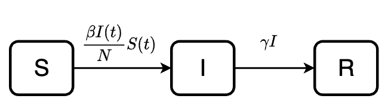

The model equations are:

$$\frac{dS(t)}{dt} = -\lambda S(t) =
-\frac{\beta I(t)}{N}S(t)$$
$$\frac{dI(t)}{dt} = \frac{\beta I(t)}{N}S - \gamma
I(t)$$
$$\frac{dR(t)}{dt} = \gamma
I(t)$$

- $N$: total population size, $N = S + I + R$
- $\beta$: the product of contact rates and transmission probability; usually we define $\lambda =\frac{\beta I(t)}{N}$ as the force of infection
- $\gamma$: recovery rate

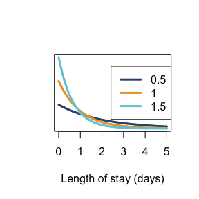

A more realistic length of stay distribution can look like this, of which most patients recovered after 4 days. We defined this using a gamma distribution with shape = 3 and rate = 1/2.

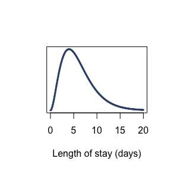

The following diagram demonstrates the model with a more realistic dwell time. The dashed arrow indicates transition described by dwell time distribution, while the solid arrow indicates transition rate.

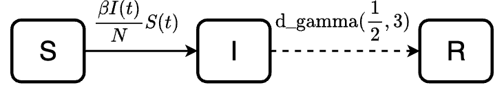

**Model specification**

*Model transition*

We have two transitions `S -> I` and `I -> R` in this case. The transitions are specified in a list follow this format `"transition" = expression`, of which expression is defined with one of our functions for waiting time distribution or a mathematical expression.

```r
transitions <- list(
  "S -> I" = "beta * S * I / N",
  "I -> R" = d_gamma(rate = 1/2, 3)
)
```

Another option to define the transitions is by using denim’s DSL. Refer to the Model definition in denim article for more information.

```r
transitions <- denim_dsl({
  S -> I = beta * (I/N) * S
  I -> R = d_gamma(rate = 1/2, shape = 3)
})
```

*Initial state*

Use a vector to define the compartments with their assigned names and initial values in the format `compartment_name = initial_value`:

```r
initialValues <- c(
  S = 999,
  I = 1,
  R = 0
)
```

*Model parameters*

If we use a math expression, any symbols except the compartment names are parameters, and would be defined by constant values. There are two constant parameters in our example: `beta` and `N`:

```r
parameters <- c(
  beta = 1.2,
  N = 1000
)
```

**Model application**

*Time step specification*

We run the model for 30 days and give output at 0.01 daily intervals. The default interval (time step) is 1 if not declared explicitly.

```r
simulationDuration <- 30
timeStep <- 0.01
```

```r
mod <- sim(transitions = transitions,
           initialValues = initialValues,
           parameters = parameters,
           simulationDuration = simulationDuration,
           timeStep = timeStep)
head(mod)
```

```
#>   Time        S        I            R
#> 1 0.00 999.0000 1.000000 0.000000e+00
#> 2 0.01 998.9880 1.011988 2.075536e-08
#> 3 0.02 998.9759 1.024119 1.656705e-07
#> 4 0.03 998.9636 1.036396 5.584446e-07
#> 5 0.04 998.9512 1.048819 1.322422e-06
#> 6 0.05 998.9386 1.061390 2.580606e-06
```

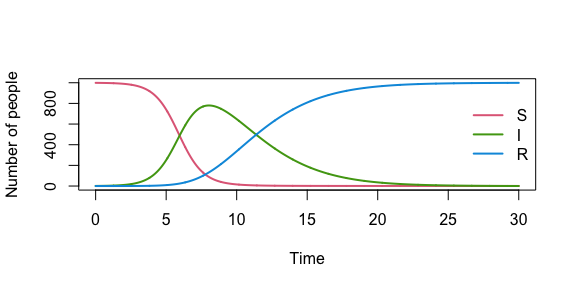

```r
plot(mod)
```

## 2. How the algorithm work?

The central idea of our algorithm is to split the compartment into a chain of sub-compartments, allowing more control over the dwell time distribution. The number of sub-compartments depends on the maximum duration an individual can stay in the compartment and the duration of time step.

At each time step, we calculate the out-going population from each sub-compartment based on the provided dwell-time distribution.

For example, if we expect a disease with a maximum 4 days of infection, and the duration of time step is 1 day, we will end up with 4 sub-compartments $I_1, I_2, I_3, I_4$. At each time step, a proportion $q_i$ of individuals in $I_i$, where $i<4$ will move to $R$ while the remaining $1-q_i$ will move to $I_{i+1}$.

Assuming we want the infectious period to follow a discrete distribution $P_I = \{p_1, p_2, p_3, p_4\}$. Our goal is to estimate $q_{1}$, $q_{2}$, $q_{3}$ such that the resulting dwell time distribution matches $P_I$.

This can be obtained by setting:

$$q_{i} = \frac{p_i}{1 -
\sum_{j=1}^{i-1}p_j}$$

The following diagram illustrates the flow between sub-compartments. Note that all individuals in $I_4$ will transition to $R$ (i.e., $q_4 = 1$)

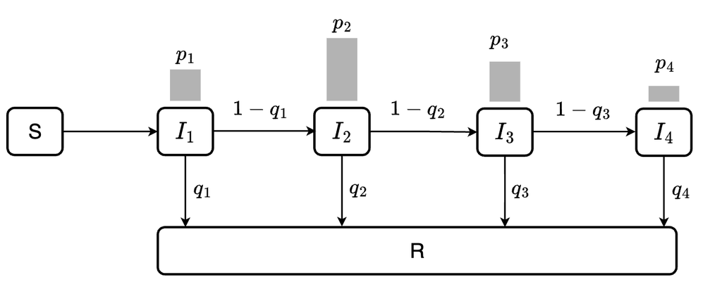

For a given dwell-time distribution, we identify the maximum length of stay using its cumulative distribution function. Because cumulative distribution function is asymptotic to 1, we need to set a value that is acceptable to be rounded to 1. If we want a cumulative probability of 0.999 to be rounded as 1, we set the error tolerance threshold as `1 - 0.999 = 0.001` (specified by the argument `errorTolerance = 0.001`). The time when cumulative probability = 0.999 will be set as the maximum length of stay of the compartment. Default `errorTolerance` of `denim` is set at `0.001`.

*Initialize population in sub-compartments*

By default, the initial population is always assigned to the first sub-compartment (for example, if the initial value for I compartment is `I = 1`, denim will initialize `I1 = 1` while `I2 = I3 = I4 = 0`).

User can also choose to distribute initial population across sub-compartments based on the specified distribution, i.e. with initial population `I = n`, then denim will initialize `I1 = n*p1`, `I2 = n*p2`, `I3 = n*p3`, `I4 = n*p4`. To set up the initial population in this way, simply specify the parameter `dist_init = TRUE` (only applicable for distribution transitions).

```r
transitions <- denim_dsl({
  S -> I = beta * S * I / N
  I -> R = d_gamma(rate = 1/2, 3, dist_init=TRUE)
})
```

## 3. Waiting time distribution

`denim` offers 2 ways to define a transition: either by a waiting time distribution in the origin compartment, or by a mathematical expression of the outgoing rate of the origin compartment.

Current available distributions in this package including:

- `d_exponential(rate)`: Discrete **exponential distribution** with parameter `rate`
- `d_gamma(rate, shape)`: Discrete **gamma distribution** with parameters `rate` and `shape`
- `d_weibull(scale, shape)`: Discrete **Weibull distribution** with parameters `scale` and `shape`
- `d_lognormal(mu, sigma)`: Discrete **log-normal distribution** with parameters `mu` and `sigma`
- `nonparametric(waitingTimes)`: A **vector of values**, could be numbers, percentages, density of the length of stay based on real data, `denim` will convert it into a distribution. These values should: (i) corresponding to 1 time step, (ii) be chronologically ordered according to the dwell-time.

Mathematical expression: Transition can also be described using a math expression such as `beta * S * I / N`. You will need to define parameters that are not compartment names in the `parameters` argument

## 4. Multiple transitions from a compartment

In `denim`, transitions between one compartment to multiple compartments are modeled as either (i) multinomial transition or (ii) competing risks.

Consider this example:

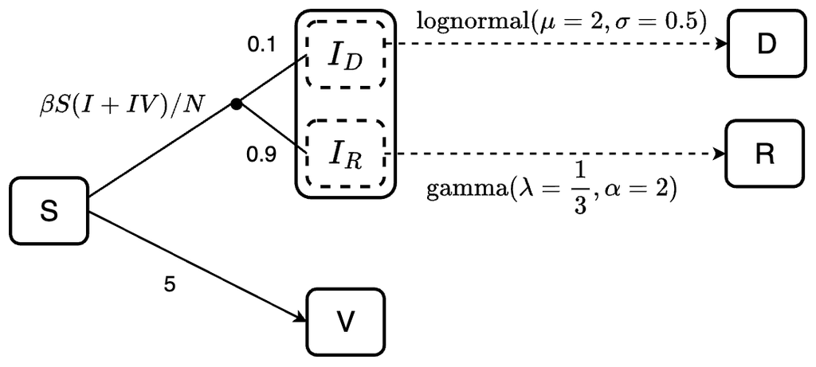

There are two scenarios in this example:

- Susceptible individuals can be infected or vaccinated. The assumption here is they will be infected first (`S -> I`), and then the rest of them who were not infected will get vaccinated (`S -> V`).
- Infected individuals can recover or die. If the mortality probability is known, we can implement it into the model. For example, here, we specify that 90% of the infected individuals will recover (sub-population $I_R$) and 10% will die (sub-population $I_D$). By doing so, we ensure that the mortality probability is 10%, while also define the length of stay of individuals at the infected state before recover or die follows gamma or log-normal distribution, respectively.

We can define the model for this example as follows:

```r
transitions <- denim_dsl({
  S -> I = beta * S * I / N
  S -> V = 5
  0.9 * I -> R = d_gamma(1/3, 2)
  0.1 * I -> D = d_lognormal(2, 0.5)
})

initialValues <- c(
  S = 999,
  I = 1,
  R = 0,
  V = 0,
  D = 0
)

parameters <- c(
  beta = 1.2,
  N = 1000
)

simulationDuration <- 20
timeStep <- 0.01

mod <- sim(transitions = transitions,
           initialValues = initialValues,
           parameters = parameters,
           simulationDuration = simulationDuration,
           timeStep = timeStep)

head(mod)
```

```
#>   Time        S        I    V            R            D
#> 1 0.00 999.0000 1.000000 0.00 0.000000e+00 0.000000e+00
#> 2 0.01 998.9380 1.011983 0.05 4.988903e-06 0.000000e+00
#> 3 0.02 998.8759 1.024099 0.10 1.997114e-05 1.466074e-33
#> 4 0.03 998.8136 1.036349 0.15 4.500034e-05 1.651885e-29
#> 5 0.04 998.7512 1.048736 0.20 8.013109e-05 8.335817e-27
#> 6 0.05 998.6886 1.061259 0.25 1.254190e-04 8.306459e-25
```

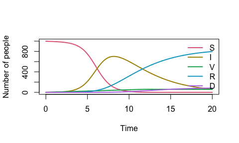

```r
plot(mod, ylim = c(0, 1000))
```

For a more detailed explanation for transitions to multiple states, refer to this article

## 5. Additional examples

### Example 1

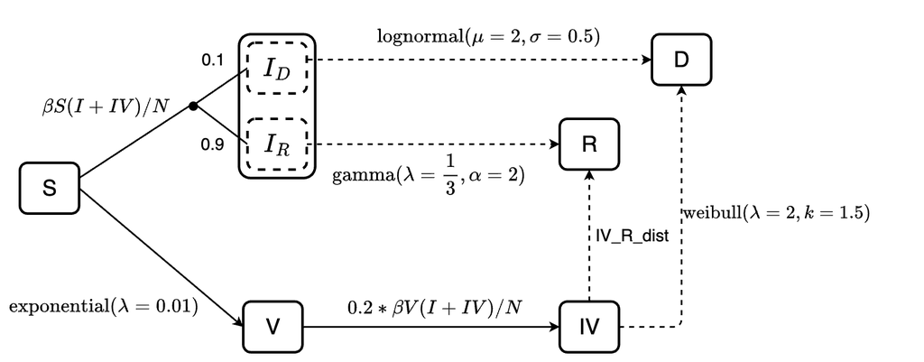

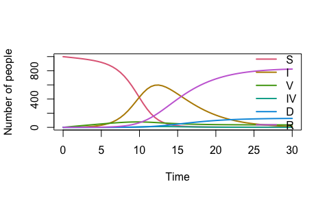

```r
initialValues <- c(S = 999, I = 1, R = 0, V = 0, IV = 0, D = 0)

modelStructure <- denim_dsl({
    S -> I = beta * S * (I + IV) / N
    S -> V = d_exponential(0.01)
    0.1 * I -> D = d_lognormal(2, 0.5)
    0.9 * I -> R = d_gamma(1/3, 2)
    V -> IV = 0.2 * beta * V * (I + IV) / N
    IV -> R = nonparametric(iv_r_dist)
    IV -> D = d_weibull(scale = 2, shape = 1.5)
})

parameters <- list(
  beta = 0.9,
  N = 1000,
  iv_r_dist = c(0, 0.15, 0.15,  0.05, 0.2, 0.2, 0.25)
)


simulation <- sim(transitions = modelStructure,
           initialValues = initialValues,
           parameters = parameters,
           simulationDuration = 30,
           timeStep = 0.5)

plot(simulation)
```

```r
head(simulation)
```

```
#>   Time        S        I         V          IV            D          R
#> 1  0.0 999.0000 1.000000  0.000000 0.000000000 0.000000e+00 0.00000000
#> 2  0.5 993.5679 1.438356  4.982533 0.000000000 3.596257e-09 0.01119419
#> 3  1.0 987.9694 2.047449  9.937329 0.000644999 3.168741e-06 0.04519477
#> 4  1.5 982.1313 2.896691 14.863015 0.002400942 1.485812e-04 0.10643758
#> 5  2.0 975.9516 4.081608 19.757537 0.005862060 8.892757e-04 0.20247704
#> 6  2.5 969.2889 5.733429 24.617848 0.011942863 3.047690e-03 0.34481256
```

### Example 2

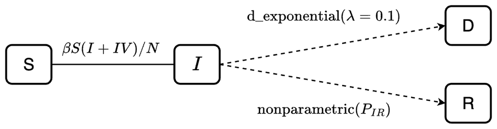

Assuming we have the distribution of time for the infected to recover ($P_{IR}$) as followed

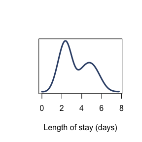

```r
timestep <- 0.05
plot(seq(0, by = 0.05, length.out = length(ir_dist)),
     ir_dist,
     type = "l", col = "#374F77", lty = 1, lwd = 3,
     xlab = "Length of stay (days)", ylab = "", yaxt = 'n')
```

This distribution can be used directly for modeling with the `nonparametric()` function. Note that when using `nonparametric()`, we must define the simulation `timeStep` to match the time resolution of the distribution data.

For example, the provided distribution is given with the interval of 0.05 day, we must set `timeStep = 0.05`.

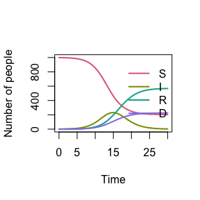

```r
transitions <- denim_dsl({
  S -> I = beta*I/N*S
  I -> R = nonparametric(ir_dist)
  I -> D = d_exponential(d_rate)
})

parameters <- list(
  beta = 0.7,
  ir_dist = ir_dist,
  d_rate = 0.1,
  N = 1000
)

initialValues <- c(
  S = 999,
  I = 1,
  R = 0,
  D = 0
)

simulationDuration <- 30
timeStep <- 0.05

mod <- sim(transitions = transitions,
           initialValues = initialValues,
           parameters = parameters,
           simulationDuration = simulationDuration,
           timeStep = timeStep)

plot(mod, ylim = c(0, 1000))
```